# Technology innovations in hydropower

Fredrik Storihle

# Abstract

This study analyzes how advances in technology have improved the efficiency of extracting power from hydroplants in Norway. I’ve used data on hydroplants supplied by NVE. I found no evidence of increased power extraction with newer parts with both a simple linear model and a loess model. A reason for this might be that innovations have been made in other terms than extraction, for example, costs.

# Introduction

In this analysis, we will look at the generation of power from the hydro plants in Norway. Hydropower is important to Norway and is currently its primary source of electricity. Hydropower is generated from dropping water from a certain height down on a turbine that spins around, generating mechanical energy, which then transforms into electricity in a generator. (statkraft, s.a.)

With such a long history of hydropower, the technology involved and know-how have evolved significantly. Even though most of the electricity generation is based on the height of the drop and amount of water, we can test how much the advances in technology have helped to make the powerplants more efficient.

Technology such as turbines, generators, less friction, and better processes may aid in the extraction of more hydropower. However, the effects might be minor compared to increasing the height of drop or amount of water.

```r
library(tidyverse)
library(readxl)
library(lubridate)
library(boot)
set.seed(1)
```

# Datawrangling

To conduct this analysis, I’ve downloaded data from NVE on all operational hydro powerplants as of April 2021.

```r
# Load in datasets and join them together
 hydro <- read_excel("Vannkraftverk.xlsx",
                     skip = 2)

startyear_df <- read_excel("liste-nett-juli-16.xlsx")
startyear_df <- startyear_df %>%
  select(RegineNr., Idrift) %>%
  transmute(Reginenr. = RegineNr.,
            start = Idrift)


hydro <-left_join(hydro, startyear_df, by = "Reginenr.")
```

The age of the plant variable in this dataset from NVE is broken. However, I joined the data with an older version from 2016. Moreover, this made all the ages of the plants correct up until 2016. The two datasets are merged based on their “RegineNr.”, which is unique to every plant. For the plants made after 2016, the age is set equal to the year of the oldest electricity-producing part. Given that these plants are at a maximum of 4 years old, it’s reasonable to assume that very few, if any, have had parts replaced already.

```r
# Cleaning environment
rm(startyear_df)

# Filtering for kraftverk, removing 30 observations classified as pumps
hydro <- hydro %>%
  filter(Type == "Kraftverk")
```

```r
# Selecting variables
hydro <- hydro %>%
  select(Navn,
        Hovedeier,
        `Org.nr. hovedeier`,
        Fylke,
        Kommune,
        `Dato for eldste kraftproduserende del`,
        `Maks ytelse [MW]`,
        `Midl. årsproduksjon (ref. 1981-2010) [GWh]`,
        `Brutto fallhøyde [m]`,
        `Maksimal slukeevne [m3/s]`,
        Elspotområde,
        Reginenr.,
        start)

# Chaning names and setting factors
hydro <- hydro %>%
  transmute(name = factor(Navn),
         owner = factor(Hovedeier),
         orgnr = factor(`Org.nr. hovedeier`),
         county = factor(Fylke),
         municipality = factor(Kommune),
         elspotarea = factor(Elspotområde),
         ageofplant = start,
         maxgenerationMW = `Maks ytelse [MW]`,
         generation_p_a_GW = `Midl. årsproduksjon (ref. 1981-2010) [GWh]`,
         grossdrop = `Brutto fallhøyde [m]`,
         maxdischarge = `Maksimal slukeevne [m3/s]`,
         dateofpart = `Dato for eldste kraftproduserende del`)




# Removing NA values from relevant variables
hydro <- hydro[!is.na(hydro$grossdrop),]
hydro <- hydro[!is.na(hydro$maxgenerationMW),]
hydro <- hydro[!is.na(hydro$maxdischarge),]

# Replacing , with .
hydro$maxgenerationMW <- gsub(",", ".", hydro$maxgenerationMW)
hydro$grossdrop <- gsub(",", ".", hydro$grossdrop)
hydro$maxdischarge <- gsub(",", ".", hydro$maxdischarge)
hydro$generation_p_a_GW <- gsub(",", ".", hydro$generation_p_a_GW)

# Changeing to numberic instead of character
hydro$maxgenerationMW <-as.numeric(hydro$maxgenerationMW)
hydro$grossdrop <- as.numeric(hydro$grossdrop)
hydro$maxdischarge <- as.numeric(hydro$maxdischarge)
hydro$generation_p_a_GW <- as.numeric(hydro$generation_p_a_GW)

# Putting in the right grossdrop value, was 1,8
hydro[734,10] <- 180
```

To clean the data, I’ve done the following steps;

- filter for plants, removing all stations classified as pumps
- Remove rows with NA-values in variables:
  - grossdrop
  - maxgenerationMW
  - maxdischarge

```r
# Create new variable partage with the age in years of the oldest part
hydro <- hydro %>%
  mutate(partage = 2021 - year(dateofpart))

# Set the age for plants made after 2016
hydro$ageofplant <-
  ifelse(is.na(hydro$ageofplant), year(hydro$dateofpart), hydro$ageofplant)
```

```r
# Create 3 new variables
hydro <- hydro %>%
  arrange(ageofplant) %>%
  mutate(hydropower = grossdrop*maxdischarge,
         cum_gen = cumsum(maxgenerationMW),
         maxMW_hydropower = maxgenerationMW/hydropower)
```

Furthermore, I’ve created the following variables;

- partage, subtract the date of the last part replaced by 2021
- Hydropower, which is grossdrop multiplied by maxdischarge
- Cum_gen, cumulative generation in MW
- maxMW_hydropower, maxgenerationMW divided by hydropower

The variables within the final dataset are the following;

| Variable | Description |
| --- | --- |
| Name | Name of the location |
| Owner | Owner of the plant |
| Orgnr | Company ID for the owner |
| County | County location |
| Municipality | Municipality location |
| elspotarea | Elspot area that plant is connected to |
| ageofplant | Year the plant was first operative |
| maxgenerationMW | Maximum amount of MW capable of being generated |
| Maxdischarge | Waterflow in M<sup>3</sup> |
| Grossdrop | Gross height which water is dropped in meters |
| dateofpart | Date the oldest electricity-producing part was installed |
| partage | Age of the oldest electricity-producing part |
| cum_gen | Cumulative generation in MW |
| Hydropower | grossdrop multiplied by maxdischarge |
| maxMW_hydropower | maxgenerationMW divided by hydropower |

# Method

## Training & testing

To validate the models used in the analysis, we divide the data into training and testing. We then use the training data to create the model, and then we predict the model on the test set and calculate the MSE.

## k fold Cross-validation

Because the amount of data is relatively small, randomness when splitting it into testing and training have a lot of influence on the model and validation. To account for this, we run a cross-validation method where we divided into training and testing k times and calculate the average of the mean error from all the individual folds given by the formula: $CV_{(k)}=\frac{1}{k}\sum_{i=1}^{k}MSE_{i}$. (James, Witten, Tibshirani & Hastie, 2013).

# Data vizualisation

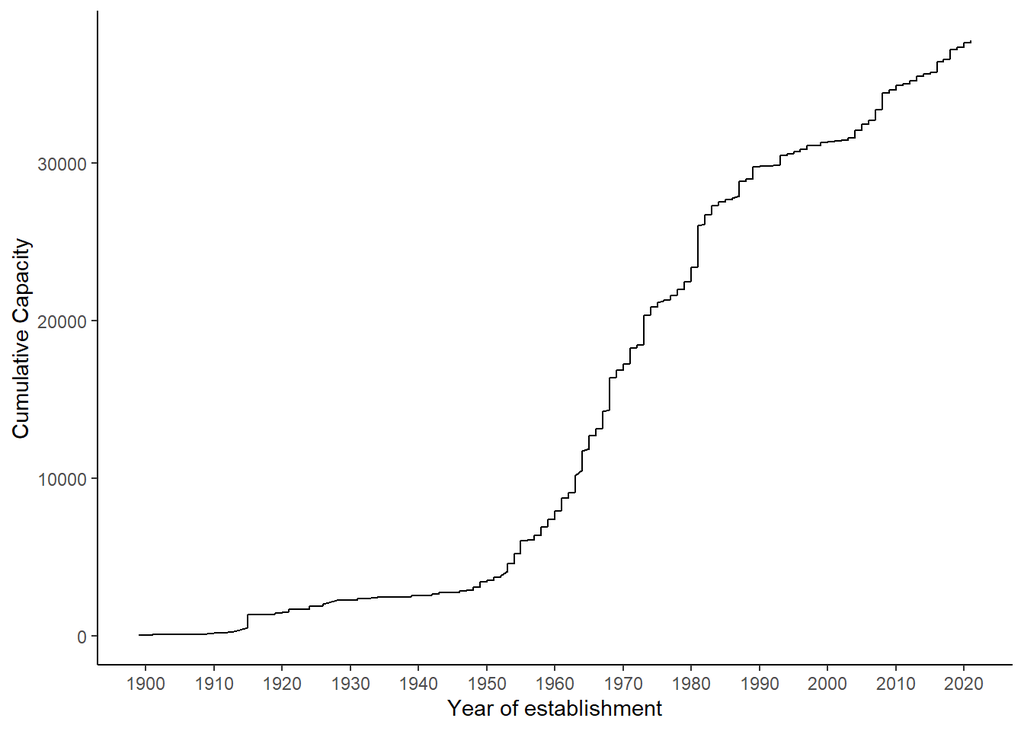

Cumulative Capacity in MW

```r
# Plot of cumulative capacity by age of plant
hydro %>%
  ggplot(.,aes(x = ageofplant, y = cum_gen)) +
  geom_line() +
  scale_x_continuous(n.breaks = 20) +
  theme_classic() +
  ylab("Cumulative Capacity") +
  xlab("Year of establishment")
```

From figure 1, we can see some trends in the industry. The first few plants from 1900- 1950 were just a few small plants. The “boom” started from 1950 and onwards, up until 1990 we can see many big hydroplants being built with large capacities, making the curve very steep upwards. However, in newer ages from 1990 and onwards, a lot of focus has been put on the environmental effects of building huge hydroplants, meeting a lot of opposition. The ecological consequences can sometimes be quite dramatic threatening fish, wilderness, and biological diversity in the nearby ecosystem.

Another factor is the number of possible locations for a plant is fixed. The most power-generating areas are likely to be exploited first, leaving smaller and less rewarding projects as time moves on. (Hofstad og Halleraker 2021)

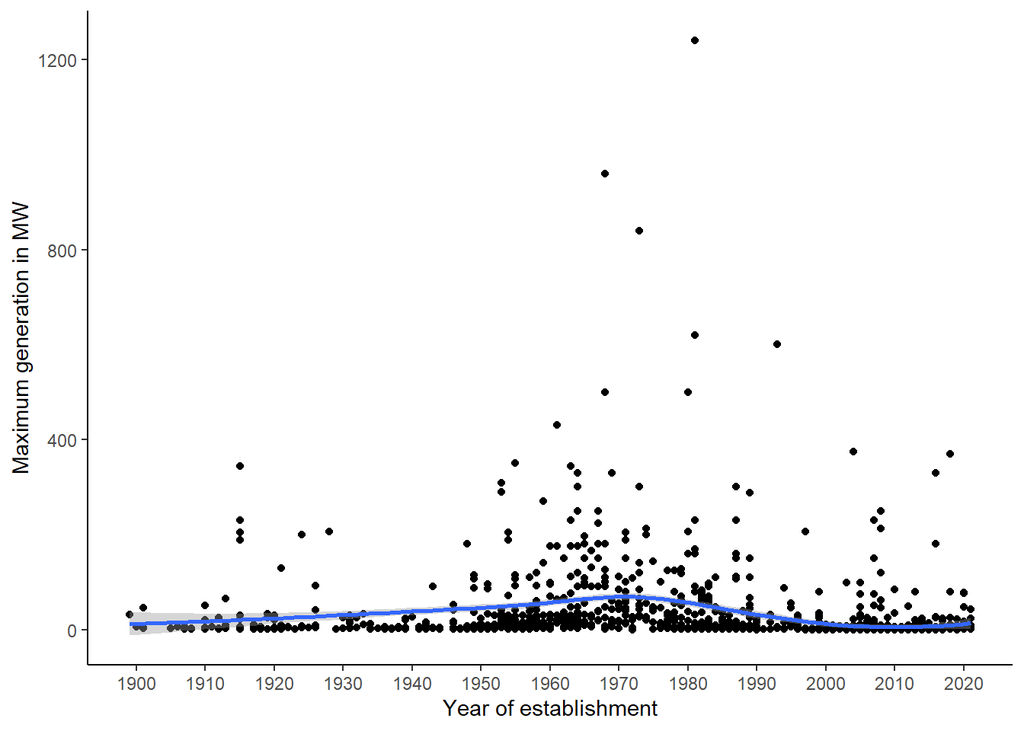

Maximum generation in MW over the years

```r
# plot of maxgenerationMW for each plant
hydro %>%
  ggplot(., aes(x = ageofplant, y = maxgenerationMW)) +
  geom_point() +
  scale_x_continuous(n.breaks = 20) +
  theme_classic() +
  geom_smooth(method="loess") +
  xlab("Year of establishment") +
  ylab("Maximum generation in MW")
```

In figure 2, we see the trend more clearly. Up until 1950, new establishments consisted of mostly smaller plants. Then there were about 40 years with larger installations and then in recent years its mostly small facilities again.

*Renewables first* explains the maximum discharge as the following formula: maxgenerationMW = maximumdischarge*grossdrop*gravity*technology

Because the size of the plants built throughout the past 120 years has varied a lot, we need a variable that lets us compare the technology differences. By dividing the maxgenerationMW variable by grossdrop multiplied by maxdischarge, we get a number that we can interpret as the efficiency of the components used allowing us to model it and compare the differences easily.  
For simplicity, we will consider gravity as equal for all plants and gross drop equivalent to net drop. (Renewables first, s.a)

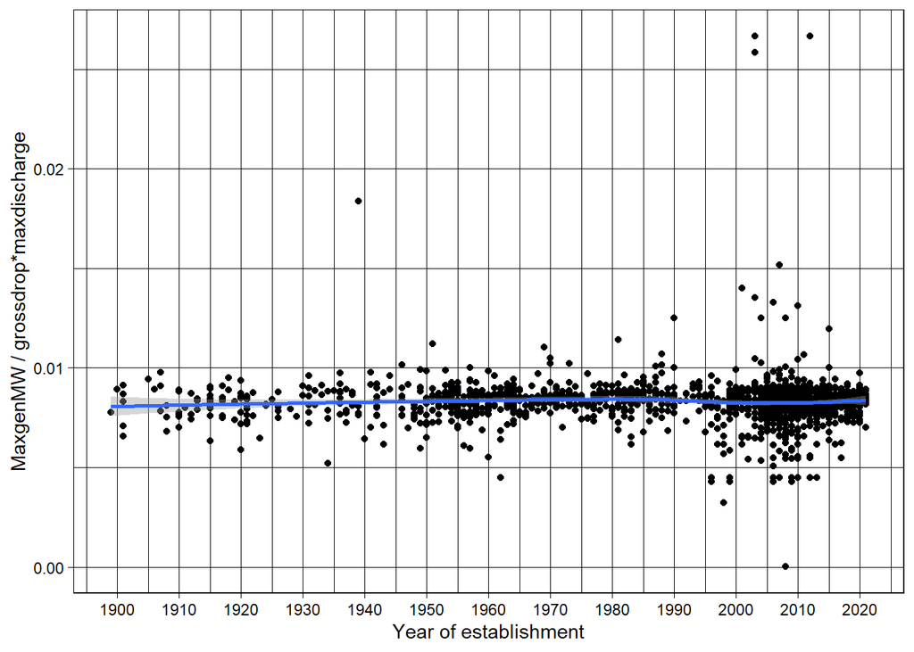

Efficiency based on plant age

```r
#Plot of efficiency based on age
hydro %>%
  ggplot(., aes(x = ageofplant, y = maxMW_hydropower)) +
  geom_point() +
  scale_x_continuous(n.breaks = 20) +
  geom_smooth(method="loess") +
  theme_linedraw() +
  xlab("Year of establishment") +
  ylab("MaxgenMW / grossdrop*maxdischarge")
```

From figure 3, we can see a very slight increase in generation given drop and flow from the oldest plants to the newest. However, it is not very convincing that the effect is significant. The variance also seems to increase with more outliers in recent years. Moreover, this might also originate from more plants being made in recent years than in later years.

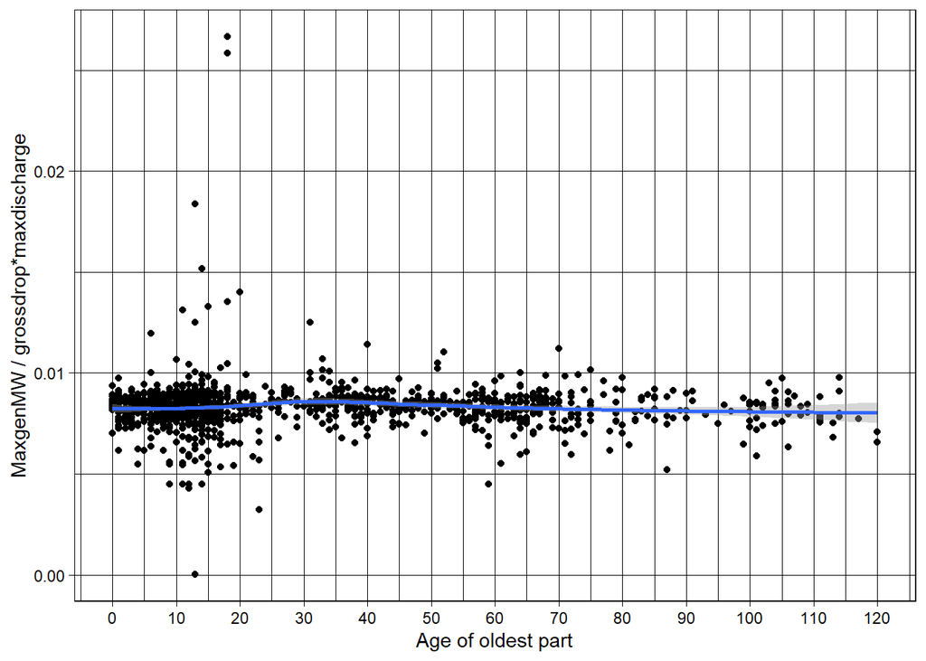

Efficiency based on oldest electricty producing part

```r
# Plot of efficiency based on oldest electricty producing part
hydro %>%
  ggplot(., aes(x = partage, y = maxMW_hydropower)) +
  geom_point() +
  scale_x_continuous(n.breaks = 20) +
  geom_smooth(method="loess") +
  theme_linedraw() +
  xlab("Age of oldest part") +
  ylab("MaxgenMW / grossdrop*maxdischarge")
```

Figure 4 looks almost the same as figure 3, given the high correlation between the age of the plant and the oldest electricity-producing parts, and the replacement rate is relatively low. However, it seems that the parts used roughly 30 years ago were slightly more efficient than those used in recent years.

# Analysis

To investigate the relationship between maxgenerationMW, partage, grossdrop, and maxdischarge. We start by making the model: $maxgenerationMW_{i} = \beta_{1}+\beta_{2}partage_{i}*\beta_{3}grossdrop_{i} * maxdischarge_{i} + \varepsilon_{i}$

```r
# LM model to see relationship between the variables
fit1 <- lm(maxgenerationMW ~ partage*grossdrop*maxdischarge,
            data = hydro)

summary(fit1)
```

```
##
## Call:
## lm(formula = maxgenerationMW ~ partage * grossdrop * maxdischarge,
##     data = hydro)
##
## Residuals:
##     Min      1Q  Median      3Q     Max
## -540.98   -2.28   -0.51    1.17  124.93
##
## Coefficients:
##                                  Estimate Std. Error t value Pr(>|t|)
## (Intercept)                    -2.038e+00  1.060e+00  -1.922 0.054743 .
## partage                         4.495e-02  2.322e-02   1.936 0.053052 .
## grossdrop                       2.477e-02  4.454e-03   5.562 3.12e-08 ***
## maxdischarge                   -5.329e-02  1.399e-02  -3.809 0.000145 ***
## partage:grossdrop              -5.096e-04  1.098e-04  -4.643 3.71e-06 ***
## partage:maxdischarge           -6.495e-05  1.974e-04  -0.329 0.742126
## grossdrop:maxdischarge          5.747e-03  1.662e-04  34.587  < 2e-16 ***
## partage:grossdrop:maxdischarge  5.605e-05  3.586e-06  15.631  < 2e-16 ***
## ---
## Signif. codes:  0 '***' 0.001 '**' 0.01 '*' 0.05 '.' 0.1 ' ' 1
##
## Residual standard error: 16.47 on 1613 degrees of freedom
## Multiple R-squared:  0.9455, Adjusted R-squared:  0.9452
## F-statistic:  3996 on 7 and 1613 DF,  p-value: < 2.2e-16
```

In this model, the partage variable also likely picks up the history of how we build hydroplants and increase the model’s bias. This is plausibly an overestimation of how significant the variable is in reality.

The last part of the variance the model doesn’t pick up is likely due to the simplifications made with not including gravity and considering net drop equal to gross drop.

Further, we will fit a model where we try to estimate the effect of just the components or technology used in creating the electricity. We estimate the following model:

$maxMW\_hydropower_{i} = \beta_{1}+\beta_{2}partage_{i}+ \varepsilon_{i}$

```r
# LM model of efficiency based on age of oldest electricty producing part
fit_lm <- glm(maxMW_hydropower ~  partage,
            data = hydro)

# Summary of the model
summary(fit_lm)
```

```
##
## Call:
## glm(formula = maxMW_hydropower ~ partage, data = hydro)
##
## Deviance Residuals:
##        Min          1Q      Median          3Q         Max
## -0.0082941  -0.0003691   0.0000408   0.0003928   0.0183570
##
## Coefficients:
##               Estimate Std. Error t value Pr(>|t|)
## (Intercept)  8.308e-03  4.847e-05 171.388   <2e-16 ***
## partage     -4.018e-07  1.197e-06  -0.336    0.737
## ---
## Signif. codes:  0 '***' 0.001 '**' 0.01 '*' 0.05 '.' 0.1 ' ' 1
##
## (Dispersion parameter for gaussian family taken to be 1.759326e-06)
##
##     Null deviance: 0.0028485  on 1620  degrees of freedom
## Residual deviance: 0.0028483  on 1619  degrees of freedom
## AIC: -16875
##
## Number of Fisher Scoring iterations: 2
```

```r
# Calcualte r squared
r2 <- with(summary(fit_lm), 1 - deviance/null.deviance)

# cross-validation with 10 folds
cv.error <- cv.glm(hydro, fit_lm, K = 10)$delta[1]
```

The coefficient is slightly negative, indicating that older parts in a linear sense are less efficient than newer ones. However, it’s not considered significant on any level. The model also takes an R-squared value of 6.960348910^{-5}, a tiny number indicating that the model explains close to zero of the variance in the model.

The partage variable does not contain bias as to how big the plants are made due to the transformation of the Y variable. In turn, this makes the partage variable less biased than in the model ran previously. Further, this provides more evidence that the technological advances made over the years, according to these models, are small in terms of power extraction.

Further, we will fit a local regression model using the same variables. The local regression model allows for a non-linear fit to the data. This will fit the data better than the linear model due to more degrees of freedom. However, due to the bias-variance trade-off, it might not make better predictions. Local linear regression uses x values that are local with a span of 0.75 in our case. Like we did for the linear model, we will use the same k-fold cross-validation method to validate this model. (James, Witten, Tibshirani & Hastie, 2013).

```r
# Local regression model same formula as linear model.
fit_loess <- loess(maxMW_hydropower ~   partage,
            data = hydro,
            control = loess.control(surface = "direct"))


# Cross-validation of the model with 10 folds
cv.error2 <- cv.glm(hydro, fit_loess, K = 10)$delta[1]
```

# Conclusion

The innovations made in the hydropower industry seem insignificant in terms of extracting more of the power. From the analysis done in this paper, we found no evidence of advancements in technology to further extract power from hydroplants in Norway. However, innovations might have come in other terms than just pure power extraction.

# Weakness with study

A weakness of the study is the data on the age of parts are aggregated. NVE only provides data stating the oldest part. The model could be more precise and sophisticated with data on all parts used and their age. Also, not including gravity in the maxgenerationMW equation and using gross drop instead of net drop makes results less precise than they could be.

# Suggestions for further study

With more data on parts at each facility and the age, we could determine if some parts are better suited than others. With more data on costs, we could also determine if replacing certain parts would be cost-effective for each hydroplant. And determine if innovations have affected costs as it looks like they have not mattered for power extraction.

# Sources

*Gareth James, Daniela Witten, Trevor Hastie, Robert Tibshirani. (2013).* *An introduction to statistical learning : with applications in R.* *New York :Springer,*

*Statkraft. (s.a.) «Vannkraft | Statkraft». Accessed on 1. june 2021* *(https://www.statkraft.com/var-virksomhet/vannkraft/).*

*Hofstad, Knut, og Jo Halvard Halleraker. 2021.* *«vannkraft». Store norske leksikon.*

*Renewables first. (s.a.) «How Much Hydropower Power Can I Get -* *Renewables First». Renewables First - The Hydro and Wind Company.* *Accessed on 1. juni 2021* *(https://www.renewablesfirst.co.uk/hydropower/hydropower-learning-centre/* *how-much-power-could-i-generate-from-a-hydro-turbine/).*